# Comparativo da evolução das receitaeitas do RJ e preço internacional do petróleo (WTI)

Juliana Santiago

6 de agosto de 2018

### TESTE receitaEITA_RJ ATÉ JARQUEBERA

#### Etapas que você seguiu

- Importar do Excel os dados mensais de receitaeita bruta do Estado do Rio de Janeiro:

#### Montando a Série de Receitas do RJ

A função `MontaSerieRJ` lê do arquivo excel referente as receitas do RJ ao longo dos anos e monta uma série temporal com base nas datas e valores.

##### Parâmetros da função:

- `filepath`: é a string que aponta para o caminho do arquivo de receitas. Por ser uma string deve ser especificado entre aspas juntamente à extesão do arquivo (ex.: “serie_historica_ate_2017.xls”);
- `comCedae`: é um valor lógico (TRUE ou FALSE). é relativo à opção de processamento sobre as receitas *com* ou *sem* cedae. Caso seja utilizado TRUE, serão utilizadas as abas da planilha que apresentem explicitamente a referência à preposição *com*, ou seja, a série será composta apenas com a cedae. Atentar para o fato de que a ausência das preposições *com* e *sem* no rótulo da aba implicam em inclusão da tabela na composição da série. De forma inversão, caso seja passado FALSE como argumento de chamada da função, a mesma processará apenas as tabelas relativas as abas que possuam em seu rótulo a preposião *sem*, além das demais tabelas que NÃO possuam *com*.

As séries são montadas de forma monolítica, ou seja, na ordem em que são lidas. A saída desta função é um `data.frame` com duas colunas (**mesAno** e **receita**).

```r
setwd("../dados")

MontaSerieReceitas <- function(filepath, comCedae = TRUE) {

    dadosReceitaRJ <- loadWorkbook(filepath, create = T)

    sheetNames <- getSheets(dadosReceitaRJ)
    numSheets <- length(excel_sheets(filepath))


    out <- data.frame(matrix(ncol = 0, nrow = 0))

    #currentYear <- yearStart
    #currentYear <- 2009

    for (i in 1:numSheets) {
        #implementando verificação pelo nome da aba
        #se tem 'com ...'
        temCom <- grepl("com", sheetNames[i], ignore.case = T)
        temSem <- grepl("sem", sheetNames[i], ignore.case = T)

        #leio abas que tem "com cedae" ou "sem cedae" comparando com parâmetro @comCedae
        #OU abas que NÃO tem nem "com cedae" e nem "sem cedae"
        if(((temCom == TRUE & comCedae == TRUE)  | (temSem == TRUE & comCedae == FALSE)) |
           (temCom == FALSE & temSem == FALSE)) {
            #quero ver abas "com cedae"
            receitaAnoRj <- readWorksheet(dadosReceitaRJ, sheet = i) %>%
            #receitaAnoRj <- readWorksheet(dadosReceitaRJ, sheet = 30) %>%
                filter(.[,1] == "Total Geral" ) %>%
                slice(1) %>%
                select(-c(1, 2, 15:ncol(.)))

            #populando saída
            df <- data.frame(matrix(nrow = 12, ncol = 2))

            #coletar o ano (XXXX) da label da aba
            anoDaAba <- substr(sheetNames[i], 1, 4)
            mesAno <- c()

            #for (j in 1:12) mesAno <- c(mesAno, paste(j,'/', currentYear, sep = ''))
            for (j in 1:12) mesAno <- c(mesAno, paste(j,'/', anoDaAba, sep = ''))

            #receita <- as.numeric(as.vector(receitaAnoRj[1,]))
            names(receitaAnoRj) <- NULL
            receita <- unlist(receitaAnoRj)

            df <- cbind(mesAno, receita)
            out <- rbind(out, df)
        }
    }
    out
}

#chamada da função 'MontaSerieReceitas'.
historico_receitas_rj <- MontaSerieReceitas(filepath = "serie_historica_ate_2017.xls", comCedae = T)

#Função que faz a substituição de '.' separando (bi)milhões e milhares e ',' por '.' como delimitador decimal.
repl = function(x)setNames(c("","."),c(".",","))[x]
historico_receitas_rj[,2] <- str_replace_all(as.character(historico_receitas_rj[,2]), "[.](?!\\d+$)|,", repl)
#Conversão da coluna de receitas de 'factor' para numeric.
historico_receitas_rj <- historico_receitas_rj %>% mutate(receita = as.numeric(receita))
rm(repl)

#historico_receitas_rj <- historico_receitas_rj %>%
#    kable("html") %>%
#    kable_styling(bootstrap_options = c("striped", "hover", "condensed", "responsive"))

historico_receitas_rj[1:10,]
```

```
##     mesAno    receita
## 1   1/2001 1238599248
## 2   2/2001 1445952867
## 3   3/2001 1334977175
## 4   4/2001 1478450743
## 5   5/2001 1366182433
## 6   6/2001 1393622404
## 7   7/2001 1298326030
## 8   8/2001 1374498764
## 9   9/2001 2092669937
## 10 10/2001 1278796592
```

#### Montando a Série de preços do WTI

Para a série do WTI utilizei a url para o `quandl`. Abaixo você pode ver um `head()` do WTI que são as primeira observações do conjunto de dados.

```r
historico_wti <- read.csv(url("https://www.quandl.com/api/v3/datasets/FRED/DCOILWTICO.csv?api_key=aMnGQskzHkeiZEeSM_zW&collapse=monthly"))

#historico_wti <- historico_wti %>%
#    kable("html") %>%
#    kable_styling(bootstrap_options = c("striped", "hover", "condensed", "responsive"))

historico_wti[1:10,]
```

```
##          Date Value
## 1  2018-08-31 69.97
## 2  2018-07-31 69.88
## 3  2018-06-30 74.13
## 4  2018-05-31 66.98
## 5  2018-04-30 68.56
## 6  2018-03-31 64.87
## 7  2018-02-28 61.43
## 8  2018-01-31 64.82
## 9  2017-12-31 60.46
## 10 2017-11-30 57.40
```

```r
# Crio as "ts" para cada série
# Os períodos para fins de composição das séries  são iguais.
ts_receitas_rj <- ts(historico_receitas_rj, start = c(2001, 1), frequency = 12)
ts_wti <-         ts(historico_wti,         start = c(1986, 1), frequency = 12)
```

- Visualizar os dados ao longo do tempo:

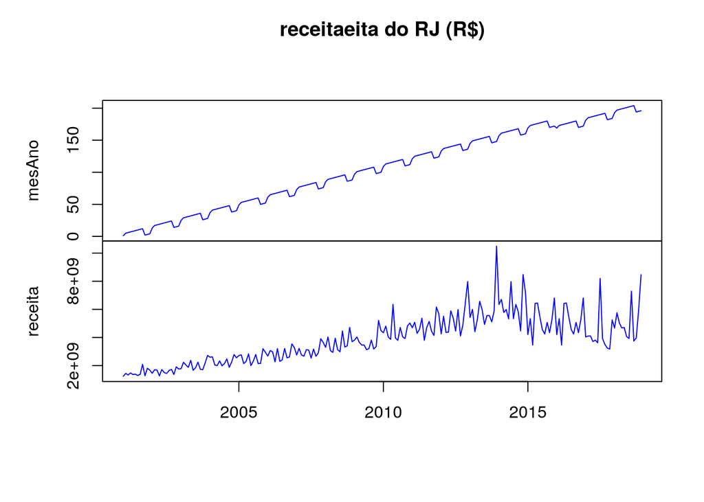

[figure not shown]

- Mostrar estatística básica:

```
## [1] "receitaeitas do RJ"
```

```
##      mesAno          receita
##  Min.   :  1.00   Min.   :1.239e+09
##  1st Qu.: 54.75   1st Qu.:2.553e+09
##  Median :108.50   Median :3.807e+09
##  Mean   :106.50   Mean   :3.873e+09
##  3rd Qu.:162.25   3rd Qu.:5.039e+09
##  Max.   :204.00   Max.   :1.049e+10
```

[output not shown]

```
##       Date            Value
##  Min.   :  1.00   Min.   : 10.25
##  1st Qu.: 98.75   1st Qu.: 19.65
##  Median :196.50   Median : 29.21
##  Mean   :196.50   Mean   : 43.84
##  3rd Qu.:294.25   3rd Qu.: 65.94
##  Max.   :392.00   Max.   :139.96
```

#### Teste de Jarque Bera

O teste de Jarque-Bera tem como hipótese nula a normalidade. Assim, se o p-valor for menor do que 5% (ou 10%), p<0,05 (p<0,10), então rejeita-se a normalidade. Já se p>0,05, aceita-se a normalidade.